# matplotlib.axes.Axes.fill_between

**Axes.fill_between(*x*, *y1*, *y2=0*, *where=None*, *interpolate=False*, *step=None*, *, *data=None*, **kwargs)[[source]](https://github.com/matplotlib/matplotlib/blob/v3.10.8/lib/matplotlib/axes/_axes.py#L5720-L5724)**

Fill the area between two horizontal curves.

The curves are defined by the points (*x*, *y1*) and (*x*, *y2*). This creates one or multiple polygons describing the filled area.

You may exclude some horizontal sections from filling using *where*.

By default, the edges connect the given points directly. Use *step* if the filling should be a step function, i.e. constant in between *x*.

**Parameters:**

**x**array-like**

The x coordinates of the nodes defining the curves.

**y1**array-like or float**

The y coordinates of the nodes defining the first curve.

**y2**array-like or float, default: 0**

The y coordinates of the nodes defining the second curve.

**where**array-like of bool, optional**

Define *where* to exclude some horizontal regions from being filled. The filled regions are defined by the coordinates `x[where]`. More precisely, fill between `x[i]` and `x[i+1]` if `where[i] and where[i+1]`. Note that this definition implies that an isolated *True* value between two *False* values in *where* will not result in filling. Both sides of the *True* position remain unfilled due to the adjacent *False* values.

**interpolate**bool, default: False**

This option is only relevant if *where* is used and the two curves are crossing each other.

Semantically, *where* is often used for *y1* > *y2* or similar. By default, the nodes of the polygon defining the filled region will only be placed at the positions in the *x* array. Such a polygon cannot describe the above semantics close to the intersection. The x-sections containing the intersection are simply clipped.

Setting *interpolate* to *True* will calculate the actual intersection point and extend the filled region up to this point.

**step**{'pre', 'post', 'mid'}, optional**

Define *step* if the filling should be a step function, i.e. constant in between *x*. The value determines where the step will occur:

- 'pre': The y value is continued constantly to the left from every *x* position, i.e. the interval `(x[i-1], x[i]]` has the value `y[i]`.
- 'post': The y value is continued constantly to the right from every *x* position, i.e. the interval `[x[i], x[i+1])` has the value `y[i]`.
- 'mid': Steps occur half-way between the *x* positions.

**Returns:**

**`FillBetweenPolyCollection`**

A `FillBetweenPolyCollection` containing the plotted polygons.

**Other Parameters:**

**data**indexable object, optional**

If given, the following parameters also accept a string `s`, which is interpreted as `data[s]` if `s` is a key in `data`:

*x*, *y1*, *y2*, *where*

**kwargs**

All other keyword arguments are passed on to `FillBetweenPolyCollection`. They control the `Polygon` properties:

| Property | Description |
| --- | --- |
| `agg_filter` | a filter function, which takes a (m, n, 3) float array and a dpi value, and returns a (m, n, 3) array and two offsets from the bottom left corner of the image |
| `alpha` | array-like or float or None |
| `animated` | bool |
| `antialiased` or `aa` or `antialiaseds` | bool or list of bools |
| `array` | array-like or None |
| `capstyle` | `CapStyle` or {'butt', 'projecting', 'round'} |
| `clim` | (vmin: float, vmax: float) |
| `clip_box` | `BboxBase` or None |
| `clip_on` | bool |
| `clip_path` | Patch or (Path, Transform) or None |
| `cmap` | `Colormap` or str or None |
| `color` | [color](https://matplotlib.org/stable/users/explain/colors/colors.html#colors-def) or list of RGBA tuples |
| `data` | array-like |
| `edgecolor` or `ec` or `edgecolors` | [color](https://matplotlib.org/stable/users/explain/colors/colors.html#colors-def) or list of [color](https://matplotlib.org/stable/users/explain/colors/colors.html#colors-def) or 'face' |
| `facecolor` or `facecolors` or `fc` | [color](https://matplotlib.org/stable/users/explain/colors/colors.html#colors-def) or list of [color](https://matplotlib.org/stable/users/explain/colors/colors.html#colors-def) |
| `figure` | `Figure` or `SubFigure` |
| `gid` | str |
| `hatch` | {'/', '\', '\|', '-', '+', 'x', 'o', 'O', '.', '*'} |
| `hatch_linewidth` | unknown |
| `in_layout` | bool |
| `joinstyle` | `JoinStyle` or {'miter', 'round', 'bevel'} |
| `label` | object |
| `linestyle` or `dashes` or `linestyles` or `ls` | str or tuple or list thereof |
| `linewidth` or `linewidths` or `lw` | float or list of floats |
| `mouseover` | bool |
| `norm` | `Normalize` or str or None |
| `offset_transform` or `transOffset` | `Transform` |
| `offsets` | (N, 2) or (2,) array-like |
| `path_effects` | list of `AbstractPathEffect` |
| `paths` | list of array-like |
| `picker` | None or bool or float or callable |
| `pickradius` | float |
| `rasterized` | bool |
| `sizes` | [`numpy.ndarray`](https://numpy.org/doc/stable/reference/generated/numpy.ndarray.html#numpy.ndarray) or None |
| `sketch_params` | (scale: float, length: float, randomness: float) |
| `snap` | bool or None |
| `transform` | `Transform` |
| `url` | str |
| `urls` | list of str or None |
| `verts` | list of array-like |
| `verts_and_codes` | unknown |
| `visible` | bool |
| `zorder` | float |

See also

**`fill_between`**

Fill between two sets of y-values.

**`fill_betweenx`**

Fill between two sets of x-values.

## Examples using `matplotlib.axes.Axes.fill_between`

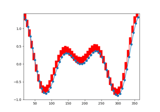

[Resampling Data](https://matplotlib.org/stable/gallery/event_handling/resample.html)

Resampling Data

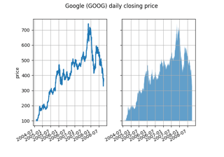

[fill_between with transparency](https://matplotlib.org/stable/gallery/lines_bars_and_markers/fill_between_alpha.html)

fill_between with transparency

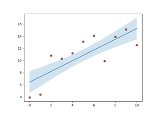

[Fill the area between two lines](https://matplotlib.org/stable/gallery/lines_bars_and_markers/fill_between_demo.html)

Fill the area between two lines

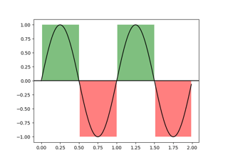

[Shade regions defined by a logical mask using fill_between](https://matplotlib.org/stable/gallery/lines_bars_and_markers/span_regions.html)

Shade regions defined by a logical mask using fill_between

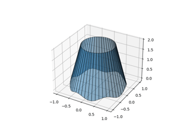

[Fill between 3D lines](https://matplotlib.org/stable/gallery/mplot3d/fillbetween3d.html)

Fill between 3D lines

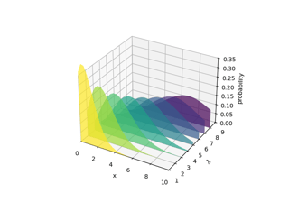

[Fill under 3D line graphs](https://matplotlib.org/stable/gallery/mplot3d/fillunder3d.html)

Fill under 3D line graphs

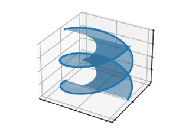

[fill_between(x1, y1, z1, x2, y2, z2)](https://matplotlib.org/stable/plot_types/3D/fill_between3d_simple.html)

fill_between(x1, y1, z1, x2, y2, z2)

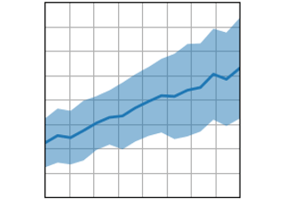

[fill_between(x, y1, y2)](https://matplotlib.org/stable/plot_types/basic/fill_between.html)

fill_between(x, y1, y2)

© 2012–2026 Matplotlib Development Team. All rights reserved.  
Licensed under the Matplotlib License Agreement.  
https://matplotlib.org/stable/api/_as_gen/matplotlib.axes.Axes.fill_between.html